# R for Data Science - Model Building / Many Models

## 24. Model building

### 24. Introduction

- 이전 장에서는 선형 모델의 작동 방식을 배웠고 모델이 데이터에 대해 무엇을 말하고 있는지 이해할 수 있는 기본 도구를 배웠습니다. 이전 장에서는 시뮬레이션 된 데이터 세트에 중점을 두었습니다.
- 이 장에서는 실제 데이터에 중점을두고 데이터 이해를 돕기 위해 점진적으로 모델을 구축하는 방법을 보여줍니다.
- 데이터를 패턴 및 잔차로 분할하는 모델에 대해 생각할 수 있다는 사실을 이용합니다.
- 시각화를 통해 패턴을 찾은 다음 모델을 사용하여 패턴을 구체적이고 정확하게 만듭니다.
- 그런 다음 프로세스를 반복하되 이전 응답 변수를 모델의 잔차로 대체합니다.
- 목표는 데이터의 내재적 지식에서 머리를 양적 모델의 명시적 지식으로 전환하는 것입니다. 이렇게하면 새 도메인에 쉽게 적용 할 수 있고 다른 도메인에서는 쉽게 사용할 수 있습니다.
- 매우 크고 복잡한 데이터 세트의 경우 많은 작업이 필요합니다. 확실히 대안적인 접근 방식이 있습니다.
- 더 많은 기계 학습 방식은 단순히 모델의 예측 능력에 초점을 맞추는 것입니다. 이러한 접근 방식은 블랙 박스를 생성하는 경향이 있습니다.
- 모델은 예측을 생성하는 데 실제로 도움이되지만 실제로 이유를 알지 못합니다. 이것은 완전히 합리적인 접근 방식이지만 실제 지식을 모델에 적용하는 것을 어렵게 만듭니다.
- 그 결과, 펀더멘털이 변함에 따라 모델이 장기간에 걸쳐 계속해서 작동 할 것인가를 평가하는 것이 어려워집니다.
- 대부분의 실제 모델에서는 이 접근 방식과보다 고전적인 자동화 된 접근 방식을 조합하여 사용할 것을 기대합니다.
- 멈추어야 할 때를 알기 란 쉽지 않습니다. 당신은 당신의 모델이 충분히 좋은 시점과 추가적인 투자가 성사 될 것 같지 않은 때를 알아 내야합니다.

### 24.1.1 Prerequisites

- 이전 장에서 사용한 도구와 동일한 도구를 사용하지만 실제 데이터 세트 (ggplot2의 다이아몬드 및 nycflights13의 항공편)를 추가합니다.
- 또한 항공편의 날짜 / 시간을 사용하려면 lubridate가 필요합니다.

```r
library(tidyverse)
library(modelr)
options(na.action = na.warn)

library(nycflights13)
library(lubridate)
```

### 24.2 Why are low quality diamonds more expensive?

- 이전 장에서 우리는 다이아몬드의 품질과 그 가격 사이의 놀라운 관계를 보았습니다
- 품질이 낮은 다이아몬드 (빈약 한 컷, 나쁜 색상 및 열등한 선명도)는 가격이 높습니다.

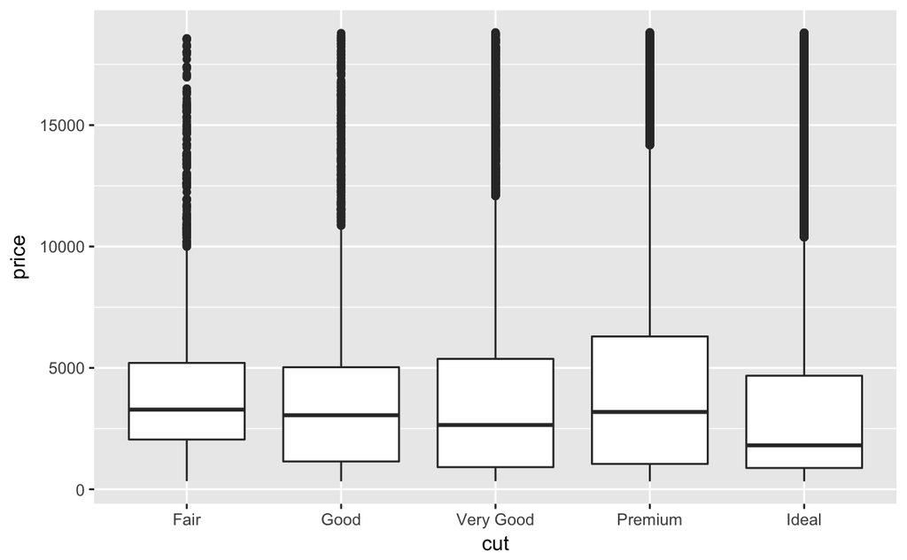

```r
ggplot(diamonds, aes(cut, price)) + geom_boxplot()
```

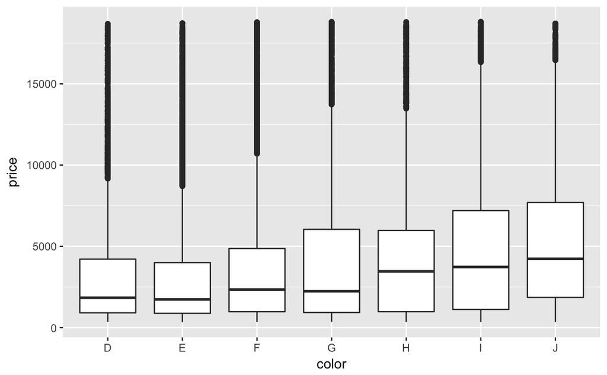

```r
ggplot(diamonds, aes(color, price)) + geom_boxplot()
```

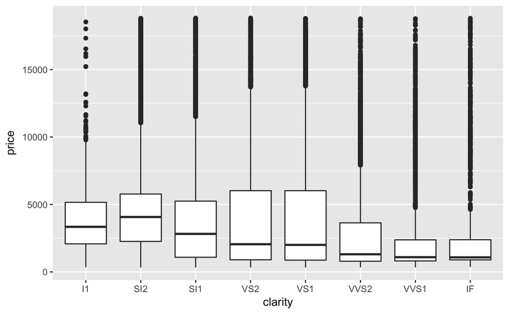

```r
ggplot(diamonds, aes(clarity, price)) + geom_boxplot()
```

- 최악의 다이아몬드 색상은 J (약간 노란색)이며 최악의 선명도는 I1 (육안으로 볼 수있는 개재물)입니다.

### 24.2.1 Price and carat

- 중요한 교란 변수인 다이아몬드의 무게 (캐럿)가 있기 때문에 품질이 낮은 다이아몬드가 더 높은 가격을 갖는 것처럼 보입니다.
- 다이아몬드의 무게는 다이아몬드의 가격을 결정하는 가장 중요한 요소이며, 품질이 낮은 다이아몬드는 더 큰 경향이 있습니다.

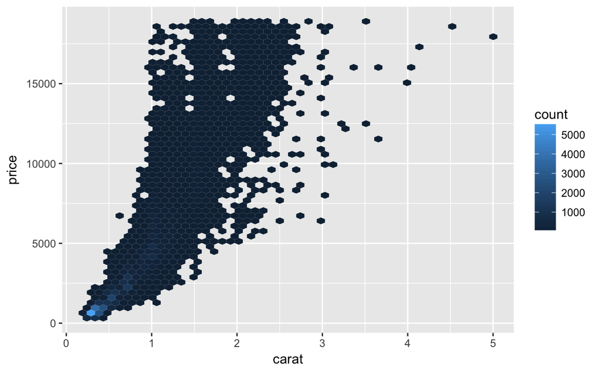

```r
ggplot(diamonds, aes(carat, price)) +
  geom_hex(bins = 50)
```

- 우리는 다이아몬드의 다른 속성이 캐럿의 효과를 분리하는 모델을 피팅함으로써 상대적인 가격에 어떻게 영향을 미치는지 쉽게 알 수 있습니다.
- 하지만 먼저 다이아몬드 데이터 세트를 조작하여 작업하기 쉽도록 두 번 조정하십시오.
- 캐럿 미만의 다이아몬드에 집중 (데이터의 99.7 %)
- 캐럿 및 가격 변수를 로그 변환합니다.

```r
diamonds2 <- diamonds %>%
  filter(carat <= 2.5) %>%
  mutate(lprice = log2(price), lcarat = log2(carat))
ggplot(diamonds2, aes(lcarat, lprice)) +
  geom_hex(bins = 50)
```

[output not shown]